# Risk Factor Analysis

## Outcome Variable

**Outcome Variable:** ever_stunted

## Predictor Variables

**Intervention Variable:** exclfeed36

**Adjustment Set:**

- arm
- W_mage
- meducyrs
- feducyrs
- hhwealth_quart
- hfoodsec
- W_mhtcm
- vagbrth
- W_gagebrth
- W_birthwt
- W_birthlen
- W_nrooms
- W_nchldlt5
- month
- brthmon
- W_parity
- impfloor
- impsan
- safeh20
- delta_W_mage
- delta_meducyrs
- delta_feducyrs
- delta_hhwealth_quart
- delta_hfoodsec
- delta_W_mhtcm
- delta_vagbrth
- delta_W_gagebrth
- delta_W_birthwt
- delta_W_birthlen
- delta_W_nrooms
- delta_W_nchldlt5
- delta_month
- delta_brthmon
- delta_W_parity
- delta_impfloor
- delta_impsan
- delta_safeh20

## Stratifying Variables

The analysis was stratified on these variable(s):

- agecat
- studyid
- country

## Data Summary

| agecat | studyid | country | exclfeed36 | ever_stunted | n_cell | n |
| --- | --- | --- | --- | --- | --- | --- |
| 0-24 months (no birth st.) | ki0047075b-MAL-ED | BANGLADESH | 1 | 0 | 24 | 209 |
| 0-24 months (no birth st.) | ki0047075b-MAL-ED | BANGLADESH | 1 | 1 | 29 | 209 |
| 0-24 months (no birth st.) | ki0047075b-MAL-ED | BANGLADESH | 0 | 0 | 74 | 209 |
| 0-24 months (no birth st.) | ki0047075b-MAL-ED | BANGLADESH | 0 | 1 | 82 | 209 |
| 0-24 months (no birth st.) | ki0047075b-MAL-ED | BRAZIL | 1 | 0 | 13 | 202 |
| 0-24 months (no birth st.) | ki0047075b-MAL-ED | BRAZIL | 1 | 1 | 1 | 202 |
| 0-24 months (no birth st.) | ki0047075b-MAL-ED | BRAZIL | 0 | 0 | 161 | 202 |
| 0-24 months (no birth st.) | ki0047075b-MAL-ED | BRAZIL | 0 | 1 | 27 | 202 |
| 0-24 months (no birth st.) | ki0047075b-MAL-ED | INDIA | 1 | 0 | 2 | 202 |
| 0-24 months (no birth st.) | ki0047075b-MAL-ED | INDIA | 1 | 1 | 2 | 202 |
| 0-24 months (no birth st.) | ki0047075b-MAL-ED | INDIA | 0 | 0 | 92 | 202 |
| 0-24 months (no birth st.) | ki0047075b-MAL-ED | INDIA | 0 | 1 | 106 | 202 |
| 0-24 months (no birth st.) | ki0047075b-MAL-ED | NEPAL | 1 | 0 | 11 | 211 |
| 0-24 months (no birth st.) | ki0047075b-MAL-ED | NEPAL | 1 | 1 | 4 | 211 |
| 0-24 months (no birth st.) | ki0047075b-MAL-ED | NEPAL | 0 | 0 | 145 | 211 |
| 0-24 months (no birth st.) | ki0047075b-MAL-ED | NEPAL | 0 | 1 | 51 | 211 |
| 0-24 months (no birth st.) | ki0047075b-MAL-ED | PERU | 1 | 0 | 5 | 252 |
| 0-24 months (no birth st.) | ki0047075b-MAL-ED | PERU | 1 | 1 | 9 | 252 |
| 0-24 months (no birth st.) | ki0047075b-MAL-ED | PERU | 0 | 0 | 97 | 252 |
| 0-24 months (no birth st.) | ki0047075b-MAL-ED | PERU | 0 | 1 | 141 | 252 |
| 0-24 months (no birth st.) | ki0047075b-MAL-ED | SOUTH AFRICA | 1 | 0 | 0 | 252 |
| 0-24 months (no birth st.) | ki0047075b-MAL-ED | SOUTH AFRICA | 1 | 1 | 0 | 252 |
| 0-24 months (no birth st.) | ki0047075b-MAL-ED | SOUTH AFRICA | 0 | 0 | 115 | 252 |
| 0-24 months (no birth st.) | ki0047075b-MAL-ED | SOUTH AFRICA | 0 | 1 | 137 | 252 |
| 0-24 months (no birth st.) | ki0047075b-MAL-ED | TANZANIA, UNITED REPUBLIC OF | 1 | 0 | 0 | 214 |
| 0-24 months (no birth st.) | ki0047075b-MAL-ED | TANZANIA, UNITED REPUBLIC OF | 1 | 1 | 1 | 214 |
| 0-24 months (no birth st.) | ki0047075b-MAL-ED | TANZANIA, UNITED REPUBLIC OF | 0 | 0 | 36 | 214 |
| 0-24 months (no birth st.) | ki0047075b-MAL-ED | TANZANIA, UNITED REPUBLIC OF | 0 | 1 | 177 | 214 |
| 0-24 months (no birth st.) | ki1000108-CMC-V-BCS-2002 | INDIA | 1 | 0 | 1 | 6 |
| 0-24 months (no birth st.) | ki1000108-CMC-V-BCS-2002 | INDIA | 1 | 1 | 5 | 6 |

[output cut: 174 more lines]

The following strata were considered:

- agecat: 0-24 months (no birth st.), studyid: ki0047075b-MAL-ED, country: BANGLADESH
- agecat: 0-24 months (no birth st.), studyid: ki0047075b-MAL-ED, country: BRAZIL
- agecat: 0-24 months (no birth st.), studyid: ki0047075b-MAL-ED, country: INDIA
- agecat: 0-24 months (no birth st.), studyid: ki0047075b-MAL-ED, country: NEPAL
- agecat: 0-24 months (no birth st.), studyid: ki0047075b-MAL-ED, country: PERU
- agecat: 0-24 months (no birth st.), studyid: ki0047075b-MAL-ED, country: SOUTH AFRICA
- agecat: 0-24 months (no birth st.), studyid: ki0047075b-MAL-ED, country: TANZANIA, UNITED REPUBLIC OF
- agecat: 0-24 months (no birth st.), studyid: ki1000108-CMC-V-BCS-2002, country: INDIA
- agecat: 0-24 months (no birth st.), studyid: ki1000108-IRC, country: INDIA
- agecat: 0-24 months (no birth st.), studyid: ki1000109-EE, country: PAKISTAN
- agecat: 0-24 months (no birth st.), studyid: ki1000304b-SAS-FoodSuppl, country: INDIA
- agecat: 0-24 months (no birth st.), studyid: ki1017093b-PROVIDE, country: BANGLADESH
- agecat: 0-24 months (no birth st.), studyid: ki1101329-Keneba, country: GAMBIA
- agecat: 0-24 months (no birth st.), studyid: ki1113344-GMS-Nepal, country: NEPAL
- agecat: 0-24 months (no birth st.), studyid: ki1148112-LCNI-5, country: MALAWI
- agecat: 0-24 months (no birth st.), studyid: kiGH5241-JiVitA-3, country: BANGLADESH
- agecat: 0-24 months (no birth st.), studyid: kiGH5241-JiVitA-4, country: BANGLADESH
- agecat: 0-6 months (no birth st.), studyid: ki0047075b-MAL-ED, country: BANGLADESH
- agecat: 0-6 months (no birth st.), studyid: ki0047075b-MAL-ED, country: BRAZIL
- agecat: 0-6 months (no birth st.), studyid: ki0047075b-MAL-ED, country: INDIA
- agecat: 0-6 months (no birth st.), studyid: ki0047075b-MAL-ED, country: NEPAL
- agecat: 0-6 months (no birth st.), studyid: ki0047075b-MAL-ED, country: PERU
- agecat: 0-6 months (no birth st.), studyid: ki0047075b-MAL-ED, country: SOUTH AFRICA
- agecat: 0-6 months (no birth st.), studyid: ki0047075b-MAL-ED, country: TANZANIA, UNITED REPUBLIC OF
- agecat: 0-6 months (no birth st.), studyid: ki1000108-CMC-V-BCS-2002, country: INDIA
- agecat: 0-6 months (no birth st.), studyid: ki1000108-IRC, country: INDIA
- agecat: 0-6 months (no birth st.), studyid: ki1000109-EE, country: PAKISTAN
- agecat: 0-6 months (no birth st.), studyid: ki1000304b-SAS-FoodSuppl, country: INDIA
- agecat: 0-6 months (no birth st.), studyid: ki1017093b-PROVIDE, country: BANGLADESH
- agecat: 0-6 months (no birth st.), studyid: ki1101329-Keneba, country: GAMBIA
- agecat: 0-6 months (no birth st.), studyid: ki1113344-GMS-Nepal, country: NEPAL
- agecat: 0-6 months (no birth st.), studyid: ki1148112-LCNI-5, country: MALAWI
- agecat: 0-6 months (no birth st.), studyid: kiGH5241-JiVitA-3, country: BANGLADESH
- agecat: 0-6 months (no birth st.), studyid: kiGH5241-JiVitA-4, country: BANGLADESH
- agecat: 6-24 months, studyid: ki0047075b-MAL-ED, country: BANGLADESH
- agecat: 6-24 months, studyid: ki0047075b-MAL-ED, country: BRAZIL
- agecat: 6-24 months, studyid: ki0047075b-MAL-ED, country: INDIA
- agecat: 6-24 months, studyid: ki0047075b-MAL-ED, country: NEPAL
- agecat: 6-24 months, studyid: ki0047075b-MAL-ED, country: PERU
- agecat: 6-24 months, studyid: ki0047075b-MAL-ED, country: SOUTH AFRICA
- agecat: 6-24 months, studyid: ki0047075b-MAL-ED, country: TANZANIA, UNITED REPUBLIC OF
- agecat: 6-24 months, studyid: ki1000108-CMC-V-BCS-2002, country: INDIA
- agecat: 6-24 months, studyid: ki1000108-IRC, country: INDIA
- agecat: 6-24 months, studyid: ki1000109-EE, country: PAKISTAN
- agecat: 6-24 months, studyid: ki1000304b-SAS-FoodSuppl, country: INDIA
- agecat: 6-24 months, studyid: ki1017093b-PROVIDE, country: BANGLADESH
- agecat: 6-24 months, studyid: ki1101329-Keneba, country: GAMBIA
- agecat: 6-24 months, studyid: ki1113344-GMS-Nepal, country: NEPAL
- agecat: 6-24 months, studyid: ki1148112-LCNI-5, country: MALAWI
- agecat: 6-24 months, studyid: kiGH5241-JiVitA-3, country: BANGLADESH
- agecat: 6-24 months, studyid: kiGH5241-JiVitA-4, country: BANGLADESH

### Dropped Strata

Some strata were dropped due to rare outcomes:

- agecat: 0-24 months (no birth st.), studyid: ki0047075b-MAL-ED, country: BRAZIL
- agecat: 0-24 months (no birth st.), studyid: ki0047075b-MAL-ED, country: INDIA
- agecat: 0-24 months (no birth st.), studyid: ki0047075b-MAL-ED, country: NEPAL
- agecat: 0-24 months (no birth st.), studyid: ki0047075b-MAL-ED, country: SOUTH AFRICA
- agecat: 0-24 months (no birth st.), studyid: ki0047075b-MAL-ED, country: TANZANIA, UNITED REPUBLIC OF
- agecat: 0-24 months (no birth st.), studyid: ki1000108-CMC-V-BCS-2002, country: INDIA
- agecat: 0-24 months (no birth st.), studyid: ki1000108-IRC, country: INDIA
- agecat: 0-24 months (no birth st.), studyid: ki1000304b-SAS-FoodSuppl, country: INDIA
- agecat: 0-6 months (no birth st.), studyid: ki0047075b-MAL-ED, country: BRAZIL
- agecat: 0-6 months (no birth st.), studyid: ki0047075b-MAL-ED, country: INDIA
- agecat: 0-6 months (no birth st.), studyid: ki0047075b-MAL-ED, country: NEPAL
- agecat: 0-6 months (no birth st.), studyid: ki0047075b-MAL-ED, country: SOUTH AFRICA
- agecat: 0-6 months (no birth st.), studyid: ki0047075b-MAL-ED, country: TANZANIA, UNITED REPUBLIC OF
- agecat: 0-6 months (no birth st.), studyid: ki1000108-CMC-V-BCS-2002, country: INDIA
- agecat: 0-6 months (no birth st.), studyid: ki1000108-IRC, country: INDIA
- agecat: 0-6 months (no birth st.), studyid: ki1000304b-SAS-FoodSuppl, country: INDIA
- agecat: 0-6 months (no birth st.), studyid: ki1148112-LCNI-5, country: MALAWI
- agecat: 6-24 months, studyid: ki0047075b-MAL-ED, country: BRAZIL
- agecat: 6-24 months, studyid: ki0047075b-MAL-ED, country: INDIA
- agecat: 6-24 months, studyid: ki0047075b-MAL-ED, country: NEPAL
- agecat: 6-24 months, studyid: ki0047075b-MAL-ED, country: PERU
- agecat: 6-24 months, studyid: ki0047075b-MAL-ED, country: SOUTH AFRICA
- agecat: 6-24 months, studyid: ki0047075b-MAL-ED, country: TANZANIA, UNITED REPUBLIC OF
- agecat: 6-24 months, studyid: ki1000108-CMC-V-BCS-2002, country: INDIA
- agecat: 6-24 months, studyid: ki1000108-IRC, country: INDIA
- agecat: 6-24 months, studyid: ki1000304b-SAS-FoodSuppl, country: INDIA

## Methods Detail

We’re interested in the causal parameters $E[Y_a]$ for all values of $a \in \mathcal{A}$. These parameters represent the mean outcome if, possibly contrary to fact, we intervened to set all units to have $A=a$. Under the randomization and positivity assumptions, these are identified by the statistical parameters $\psi_a=E_W[E_{Y|A,W}(Y|A=a,W)]$. In addition, we’re interested in the mean of $Y$, $E[Y]$ under no intervention (the observed mean). We will estimate these parameters by using SuperLearner to fit the relevant likelihood factors – $E_{Y|A,W}(Y|A=a,W)$ and $p(A=a|W)$, and then updating our likelihood fit using a joint TMLE.

For unadjusted analyses ($W=\{\}$), initial likelihoods were estimated using Lrnr_glm to estimate the simple $E(Y|A)$ and Lrnr_mean to estimate $p(A)$. For adjusted analyses, a small library containing Lrnr_glmnet, Lrnr_xgboost, and Lrnr_mean was used.

Having estimated these parameters, we will then use the delta method to estimate relative risks and attributable risks relative to a prespecified baseline level of $A$.

# Results Detail

## Results Plots

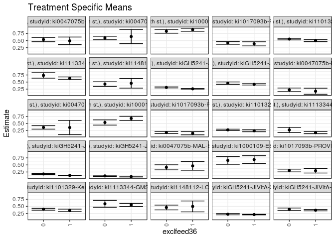

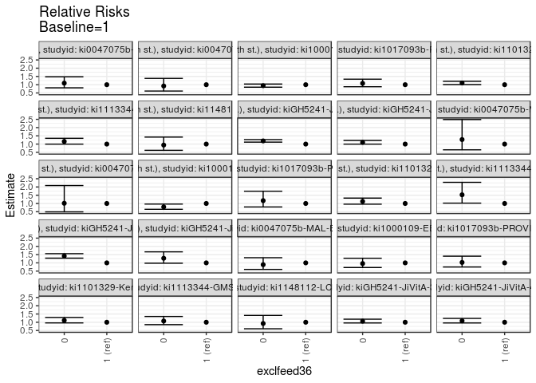

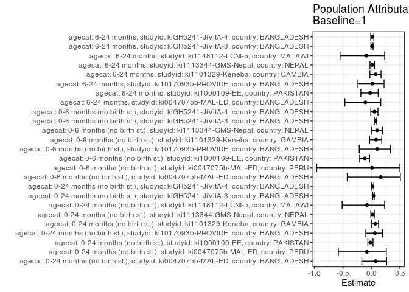

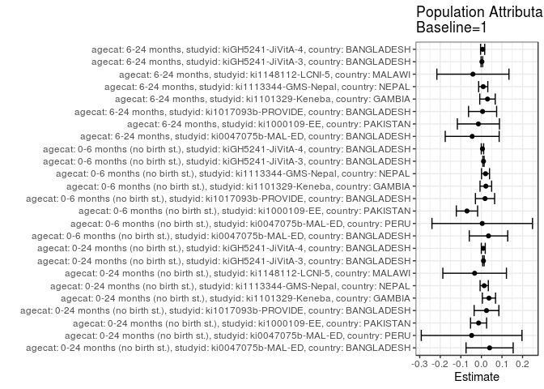

## Results Table

### Parameter: TSM

| agecat | studyid | country | intervention_level | baseline_level | estimate | ci_lower | ci_upper |
| --- | --- | --- | --- | --- | --- | --- | --- |
| 0-24 months (no birth st.) | ki0047075b-MAL-ED | BANGLADESH | 1 | NA | 0.4913536 | 0.3570481 | 0.6256592 |
| 0-24 months (no birth st.) | ki0047075b-MAL-ED | BANGLADESH | 0 | NA | 0.5375431 | 0.4612175 | 0.6138687 |
| 0-24 months (no birth st.) | ki0047075b-MAL-ED | PERU | 1 | NA | 0.6428571 | 0.3913643 | 0.8943500 |
| 0-24 months (no birth st.) | ki0047075b-MAL-ED | PERU | 0 | NA | 0.5924370 | 0.5298849 | 0.6549890 |
| 0-24 months (no birth st.) | ki1000109-EE | PAKISTAN | 1 | NA | 0.8832757 | 0.8309072 | 0.9356442 |
| 0-24 months (no birth st.) | ki1000109-EE | PAKISTAN | 0 | NA | 0.8295499 | 0.7617345 | 0.8973654 |
| 0-24 months (no birth st.) | ki1017093b-PROVIDE | BANGLADESH | 1 | NA | 0.3860502 | 0.3135511 | 0.4585493 |
| 0-24 months (no birth st.) | ki1017093b-PROVIDE | BANGLADESH | 0 | NA | 0.4173523 | 0.3712611 | 0.4634435 |
| 0-24 months (no birth st.) | ki1101329-Keneba | GAMBIA | 1 | NA | 0.5022707 | 0.4626705 | 0.5418710 |
| 0-24 months (no birth st.) | ki1101329-Keneba | GAMBIA | 0 | NA | 0.5538425 | 0.5265399 | 0.5811452 |
| 0-24 months (no birth st.) | ki1113344-GMS-Nepal | NEPAL | 1 | NA | 0.6320600 | 0.5837656 | 0.6803543 |
| 0-24 months (no birth st.) | ki1113344-GMS-Nepal | NEPAL | 0 | NA | 0.7336912 | 0.6379727 | 0.8294098 |
| 0-24 months (no birth st.) | ki1148112-LCNI-5 | MALAWI | 1 | NA | 0.4558494 | 0.2859271 | 0.6257717 |
| 0-24 months (no birth st.) | ki1148112-LCNI-5 | MALAWI | 0 | NA | 0.4287038 | 0.3477609 | 0.5096466 |
| 0-24 months (no birth st.) | kiGH5241-JiVitA-3 | BANGLADESH | 1 | NA | 0.2600350 | 0.2502972 | 0.2697728 |
| 0-24 months (no birth st.) | kiGH5241-JiVitA-3 | BANGLADESH | 0 | NA | 0.3098892 | 0.2912773 | 0.3285011 |
| 0-24 months (no birth st.) | kiGH5241-JiVitA-4 | BANGLADESH | 1 | NA | 0.4185639 | 0.3956910 | 0.4414368 |
| 0-24 months (no birth st.) | kiGH5241-JiVitA-4 | BANGLADESH | 0 | NA | 0.4621228 | 0.4207602 | 0.5034854 |
| 0-6 months (no birth st.) | ki0047075b-MAL-ED | BANGLADESH | 1 | NA | 0.1761255 | 0.0686003 | 0.2836508 |
| 0-6 months (no birth st.) | ki0047075b-MAL-ED | BANGLADESH | 0 | NA | 0.2245348 | 0.1598239 | 0.2892458 |
| 0-6 months (no birth st.) | ki0047075b-MAL-ED | PERU | 1 | NA | 0.3571429 | 0.1056500 | 0.6086357 |
| 0-6 months (no birth st.) | ki0047075b-MAL-ED | PERU | 0 | NA | 0.3613445 | 0.3001916 | 0.4224974 |
| 0-6 months (no birth st.) | ki1000109-EE | PAKISTAN | 1 | NA | 0.6784684 | 0.6026582 | 0.7542785 |
| 0-6 months (no birth st.) | ki1000109-EE | PAKISTAN | 0 | NA | 0.5355774 | 0.4433611 | 0.6277937 |
| 0-6 months (no birth st.) | ki1017093b-PROVIDE | BANGLADESH | 1 | NA | 0.1557986 | 0.0995319 | 0.2120653 |
| 0-6 months (no birth st.) | ki1017093b-PROVIDE | BANGLADESH | 0 | NA | 0.1827285 | 0.1472334 | 0.2182236 |
| 0-6 months (no birth st.) | ki1101329-Keneba | GAMBIA | 1 | NA | 0.2438194 | 0.2094679 | 0.2781708 |
| 0-6 months (no birth st.) | ki1101329-Keneba | GAMBIA | 0 | NA | 0.2745947 | 0.2500296 | 0.2991598 |
| 0-6 months (no birth st.) | ki1113344-GMS-Nepal | NEPAL | 1 | NA | 0.1783672 | 0.1400488 | 0.2166855 |
| 0-6 months (no birth st.) | ki1113344-GMS-Nepal | NEPAL | 0 | NA | 0.2722174 | 0.1795347 | 0.3649002 |
| 0-6 months (no birth st.) | kiGH5241-JiVitA-3 | BANGLADESH | 1 | NA | 0.1278527 | 0.1208585 | 0.1348469 |
| 0-6 months (no birth st.) | kiGH5241-JiVitA-3 | BANGLADESH | 0 | NA | 0.1809845 | 0.1654409 | 0.1965281 |
| 0-6 months (no birth st.) | kiGH5241-JiVitA-4 | BANGLADESH | 1 | NA | 0.0877090 | 0.0740492 | 0.1013688 |
| 0-6 months (no birth st.) | kiGH5241-JiVitA-4 | BANGLADESH | 0 | NA | 0.1120961 | 0.0873429 | 0.1368494 |
| 6-24 months | ki0047075b-MAL-ED | BANGLADESH | 1 | NA | 0.4662361 | 0.3130423 | 0.6194299 |
| 6-24 months | ki0047075b-MAL-ED | BANGLADESH | 0 | NA | 0.4154522 | 0.3264493 | 0.5044552 |
| 6-24 months | ki1000109-EE | PAKISTAN | 1 | NA | 0.6884223 | 0.5503171 | 0.8265275 |
| 6-24 months | ki1000109-EE | PAKISTAN | 0 | NA | 0.6596491 | 0.5230215 | 0.7962768 |
| 6-24 months | ki1017093b-PROVIDE | BANGLADESH | 1 | NA | 0.2947571 | 0.2137583 | 0.3757559 |
| 6-24 months | ki1017093b-PROVIDE | BANGLADESH | 0 | NA | 0.3026234 | 0.2540852 | 0.3511616 |
| 6-24 months | ki1101329-Keneba | GAMBIA | 1 | NA | 0.3581724 | 0.3126288 | 0.4037159 |
| 6-24 months | ki1101329-Keneba | GAMBIA | 0 | NA | 0.3987674 | 0.3665541 | 0.4309806 |
| 6-24 months | ki1113344-GMS-Nepal | NEPAL | 1 | NA | 0.5505570 | 0.4956042 | 0.6055097 |
| 6-24 months | ki1113344-GMS-Nepal | NEPAL | 0 | NA | 0.5913492 | 0.4694435 | 0.7132548 |
| 6-24 months | ki1148112-LCNI-5 | MALAWI | 1 | NA | 0.4982221 | 0.3060239 | 0.6904203 |
| 6-24 months | ki1148112-LCNI-5 | MALAWI | 0 | NA | 0.4610202 | 0.3765831 | 0.5454572 |
| 6-24 months | kiGH5241-JiVitA-3 | BANGLADESH | 1 | NA | 0.2098850 | 0.1986961 | 0.2210739 |
| 6-24 months | kiGH5241-JiVitA-3 | BANGLADESH | 0 | NA | 0.2235603 | 0.2012555 | 0.2458652 |
| 6-24 months | kiGH5241-JiVitA-4 | BANGLADESH | 1 | NA | 0.3645250 | 0.3416176 | 0.3874324 |
| 6-24 months | kiGH5241-JiVitA-4 | BANGLADESH | 0 | NA | 0.3959644 | 0.3500604 | 0.4418683 |

### Parameter: E(Y)

| agecat | studyid | country | intervention_level | baseline_level | estimate | ci_lower | ci_upper |
| --- | --- | --- | --- | --- | --- | --- | --- |
| 0-24 months (no birth st.) | ki0047075b-MAL-ED | BANGLADESH | NA | NA | 0.5311005 | 0.4632825 | 0.5989184 |
| 0-24 months (no birth st.) | ki0047075b-MAL-ED | PERU | NA | NA | 0.5952381 | 0.5345146 | 0.6559615 |
| 0-24 months (no birth st.) | ki1000109-EE | PAKISTAN | NA | NA | 0.8693878 | 0.8271061 | 0.9116694 |
| 0-24 months (no birth st.) | ki1017093b-PROVIDE | BANGLADESH | NA | NA | 0.4107452 | 0.3705685 | 0.4509220 |
| 0-24 months (no birth st.) | ki1101329-Keneba | GAMBIA | NA | NA | 0.5389321 | 0.5158847 | 0.5619796 |
| 0-24 months (no birth st.) | ki1113344-GMS-Nepal | NEPAL | NA | NA | 0.6455696 | 0.6024620 | 0.6886773 |
| 0-24 months (no birth st.) | ki1148112-LCNI-5 | MALAWI | NA | NA | 0.4228571 | 0.3494545 | 0.4962598 |
| 0-24 months (no birth st.) | kiGH5241-JiVitA-3 | BANGLADESH | NA | NA | 0.2699052 | 0.2606917 | 0.2791188 |
| 0-24 months (no birth st.) | kiGH5241-JiVitA-4 | BANGLADESH | NA | NA | 0.4276032 | 0.4069572 | 0.4482492 |
| 0-6 months (no birth st.) | ki0047075b-MAL-ED | BANGLADESH | NA | NA | 0.2105263 | 0.1551227 | 0.2659300 |
| 0-6 months (no birth st.) | ki0047075b-MAL-ED | PERU | NA | NA | 0.3611111 | 0.3016895 | 0.4205327 |
| 0-6 months (no birth st.) | ki1000109-EE | PAKISTAN | NA | NA | 0.6081633 | 0.5469119 | 0.6694146 |
| 0-6 months (no birth st.) | ki1017093b-PROVIDE | BANGLADESH | NA | NA | 0.1733102 | 0.1423987 | 0.2042217 |
| 0-6 months (no birth st.) | ki1101329-Keneba | GAMBIA | NA | NA | 0.2652948 | 0.2448823 | 0.2857072 |
| 0-6 months (no birth st.) | ki1113344-GMS-Nepal | NEPAL | NA | NA | 0.1983122 | 0.1623791 | 0.2342454 |
| 0-6 months (no birth st.) | kiGH5241-JiVitA-3 | BANGLADESH | NA | NA | 0.1379748 | 0.1313000 | 0.1446495 |
| 0-6 months (no birth st.) | kiGH5241-JiVitA-4 | BANGLADESH | NA | NA | 0.0927295 | 0.0806900 | 0.1047690 |
| 6-24 months | ki0047075b-MAL-ED | BANGLADESH | NA | NA | 0.4213836 | 0.3443902 | 0.4983771 |
| 6-24 months | ki1000109-EE | PAKISTAN | NA | NA | 0.6736842 | 0.5789010 | 0.7684674 |
| 6-24 months | ki1017093b-PROVIDE | BANGLADESH | NA | NA | 0.3004386 | 0.2583143 | 0.3425629 |
| 6-24 months | ki1101329-Keneba | GAMBIA | NA | NA | 0.3877069 | 0.3608893 | 0.4145245 |
| 6-24 months | ki1113344-GMS-Nepal | NEPAL | NA | NA | 0.5593668 | 0.5093185 | 0.6094150 |
| 6-24 months | ki1148112-LCNI-5 | MALAWI | NA | NA | 0.4567901 | 0.3798457 | 0.5337346 |
| 6-24 months | kiGH5241-JiVitA-3 | BANGLADESH | NA | NA | 0.2122010 | 0.2018013 | 0.2226006 |
| 6-24 months | kiGH5241-JiVitA-4 | BANGLADESH | NA | NA | 0.3704082 | 0.3493754 | 0.3914410 |

### Parameter: RR

| agecat | studyid | country | intervention_level | baseline_level | estimate | ci_lower | ci_upper |
| --- | --- | --- | --- | --- | --- | --- | --- |
| 0-24 months (no birth st.) | ki0047075b-MAL-ED | BANGLADESH | 1 | 1 | 1.0000000 | 1.0000000 | 1.0000000 |
| 0-24 months (no birth st.) | ki0047075b-MAL-ED | BANGLADESH | 0 | 1 | 1.0940045 | 0.8099899 | 1.4776058 |
| 0-24 months (no birth st.) | ki0047075b-MAL-ED | PERU | 1 | 1 | 1.0000000 | 1.0000000 | 1.0000000 |
| 0-24 months (no birth st.) | ki0047075b-MAL-ED | PERU | 0 | 1 | 0.9215686 | 0.6145365 | 1.3819987 |
| 0-24 months (no birth st.) | ki1000109-EE | PAKISTAN | 1 | 1 | 1.0000000 | 1.0000000 | 1.0000000 |
| 0-24 months (no birth st.) | ki1000109-EE | PAKISTAN | 0 | 1 | 0.9391744 | 0.8484000 | 1.0396611 |
| 0-24 months (no birth st.) | ki1017093b-PROVIDE | BANGLADESH | 1 | 1 | 1.0000000 | 1.0000000 | 1.0000000 |
| 0-24 months (no birth st.) | ki1017093b-PROVIDE | BANGLADESH | 0 | 1 | 1.0810831 | 0.8756946 | 1.3346441 |
| 0-24 months (no birth st.) | ki1101329-Keneba | GAMBIA | 1 | 1 | 1.0000000 | 1.0000000 | 1.0000000 |
| 0-24 months (no birth st.) | ki1101329-Keneba | GAMBIA | 0 | 1 | 1.1026773 | 1.0074709 | 1.2068808 |
| 0-24 months (no birth st.) | ki1113344-GMS-Nepal | NEPAL | 1 | 1 | 1.0000000 | 1.0000000 | 1.0000000 |
| 0-24 months (no birth st.) | ki1113344-GMS-Nepal | NEPAL | 0 | 1 | 1.1607937 | 0.9978251 | 1.3503791 |
| 0-24 months (no birth st.) | ki1148112-LCNI-5 | MALAWI | 1 | 1 | 1.0000000 | 1.0000000 | 1.0000000 |
| 0-24 months (no birth st.) | ki1148112-LCNI-5 | MALAWI | 0 | 1 | 0.9404503 | 0.6210840 | 1.4240374 |
| 0-24 months (no birth st.) | kiGH5241-JiVitA-3 | BANGLADESH | 1 | 1 | 1.0000000 | 1.0000000 | 1.0000000 |
| 0-24 months (no birth st.) | kiGH5241-JiVitA-3 | BANGLADESH | 0 | 1 | 1.1917210 | 1.1176964 | 1.2706482 |
| 0-24 months (no birth st.) | kiGH5241-JiVitA-4 | BANGLADESH | 1 | 1 | 1.0000000 | 1.0000000 | 1.0000000 |
| 0-24 months (no birth st.) | kiGH5241-JiVitA-4 | BANGLADESH | 0 | 1 | 1.1040675 | 0.9977971 | 1.2216562 |
| 0-6 months (no birth st.) | ki0047075b-MAL-ED | BANGLADESH | 1 | 1 | 1.0000000 | 1.0000000 | 1.0000000 |
| 0-6 months (no birth st.) | ki0047075b-MAL-ED | BANGLADESH | 0 | 1 | 1.2748570 | 0.6530939 | 2.4885555 |
| 0-6 months (no birth st.) | ki0047075b-MAL-ED | PERU | 1 | 1 | 1.0000000 | 1.0000000 | 1.0000000 |
| 0-6 months (no birth st.) | ki0047075b-MAL-ED | PERU | 0 | 1 | 1.0117647 | 0.4903994 | 2.0874166 |
| 0-6 months (no birth st.) | ki1000109-EE | PAKISTAN | 1 | 1 | 1.0000000 | 1.0000000 | 1.0000000 |
| 0-6 months (no birth st.) | ki1000109-EE | PAKISTAN | 0 | 1 | 0.7893918 | 0.6473930 | 0.9625365 |
| 0-6 months (no birth st.) | ki1017093b-PROVIDE | BANGLADESH | 1 | 1 | 1.0000000 | 1.0000000 | 1.0000000 |
| 0-6 months (no birth st.) | ki1017093b-PROVIDE | BANGLADESH | 0 | 1 | 1.1728509 | 0.7890611 | 1.7433112 |
| 0-6 months (no birth st.) | ki1101329-Keneba | GAMBIA | 1 | 1 | 1.0000000 | 1.0000000 | 1.0000000 |
| 0-6 months (no birth st.) | ki1101329-Keneba | GAMBIA | 0 | 1 | 1.1262219 | 0.9565073 | 1.3260493 |
| 0-6 months (no birth st.) | ki1113344-GMS-Nepal | NEPAL | 1 | 1 | 1.0000000 | 1.0000000 | 1.0000000 |
| 0-6 months (no birth st.) | ki1113344-GMS-Nepal | NEPAL | 0 | 1 | 1.5261634 | 1.0205190 | 2.2823434 |
| 0-6 months (no birth st.) | kiGH5241-JiVitA-3 | BANGLADESH | 1 | 1 | 1.0000000 | 1.0000000 | 1.0000000 |
| 0-6 months (no birth st.) | kiGH5241-JiVitA-3 | BANGLADESH | 0 | 1 | 1.4155703 | 1.2856017 | 1.5586782 |
| 0-6 months (no birth st.) | kiGH5241-JiVitA-4 | BANGLADESH | 1 | 1 | 1.0000000 | 1.0000000 | 1.0000000 |
| 0-6 months (no birth st.) | kiGH5241-JiVitA-4 | BANGLADESH | 0 | 1 | 1.2780462 | 0.9789826 | 1.6684689 |
| 6-24 months | ki0047075b-MAL-ED | BANGLADESH | 1 | 1 | 1.0000000 | 1.0000000 | 1.0000000 |
| 6-24 months | ki0047075b-MAL-ED | BANGLADESH | 0 | 1 | 0.8910770 | 0.6044247 | 1.3136761 |
| 6-24 months | ki1000109-EE | PAKISTAN | 1 | 1 | 1.0000000 | 1.0000000 | 1.0000000 |
| 6-24 months | ki1000109-EE | PAKISTAN | 0 | 1 | 0.9582042 | 0.7173479 | 1.2799304 |
| 6-24 months | ki1017093b-PROVIDE | BANGLADESH | 1 | 1 | 1.0000000 | 1.0000000 | 1.0000000 |
| 6-24 months | ki1017093b-PROVIDE | BANGLADESH | 0 | 1 | 1.0266872 | 0.7504406 | 1.4046236 |
| 6-24 months | ki1101329-Keneba | GAMBIA | 1 | 1 | 1.0000000 | 1.0000000 | 1.0000000 |
| 6-24 months | ki1101329-Keneba | GAMBIA | 0 | 1 | 1.1133394 | 0.9599220 | 1.2912763 |
| 6-24 months | ki1113344-GMS-Nepal | NEPAL | 1 | 1 | 1.0000000 | 1.0000000 | 1.0000000 |
| 6-24 months | ki1113344-GMS-Nepal | NEPAL | 0 | 1 | 1.0740926 | 0.8543687 | 1.3503244 |
| 6-24 months | ki1148112-LCNI-5 | MALAWI | 1 | 1 | 1.0000000 | 1.0000000 | 1.0000000 |
| 6-24 months | ki1148112-LCNI-5 | MALAWI | 0 | 1 | 0.9253306 | 0.6051184 | 1.4149905 |
| 6-24 months | kiGH5241-JiVitA-3 | BANGLADESH | 1 | 1 | 1.0000000 | 1.0000000 | 1.0000000 |
| 6-24 months | kiGH5241-JiVitA-3 | BANGLADESH | 0 | 1 | 1.0651562 | 0.9562530 | 1.1864619 |
| 6-24 months | kiGH5241-JiVitA-4 | BANGLADESH | 1 | 1 | 1.0000000 | 1.0000000 | 1.0000000 |
| 6-24 months | kiGH5241-JiVitA-4 | BANGLADESH | 0 | 1 | 1.0862474 | 0.9557033 | 1.2346231 |

### Parameter: PAR

| agecat | studyid | country | intervention_level | baseline_level | estimate | ci_lower | ci_upper |
| --- | --- | --- | --- | --- | --- | --- | --- |
| 0-24 months (no birth st.) | ki0047075b-MAL-ED | BANGLADESH | 1 | NA | 0.0397468 | -0.0748535 | 0.1543472 |
| 0-24 months (no birth st.) | ki0047075b-MAL-ED | PERU | 1 | NA | -0.0476190 | -0.2923809 | 0.1971428 |
| 0-24 months (no birth st.) | ki1000109-EE | PAKISTAN | 1 | NA | -0.0138880 | -0.0529754 | 0.0251994 |
| 0-24 months (no birth st.) | ki1017093b-PROVIDE | BANGLADESH | 1 | NA | 0.0246951 | -0.0354654 | 0.0848555 |
| 0-24 months (no birth st.) | ki1101329-Keneba | GAMBIA | 1 | NA | 0.0366614 | 0.0045952 | 0.0687276 |
| 0-24 months (no birth st.) | ki1113344-GMS-Nepal | NEPAL | 1 | NA | 0.0135097 | -0.0064842 | 0.0335035 |
| 0-24 months (no birth st.) | ki1148112-LCNI-5 | MALAWI | 1 | NA | -0.0329923 | -0.1876054 | 0.1216208 |
| 0-24 months (no birth st.) | kiGH5241-JiVitA-3 | BANGLADESH | 1 | NA | 0.0098702 | 0.0062830 | 0.0134575 |
| 0-24 months (no birth st.) | kiGH5241-JiVitA-4 | BANGLADESH | 1 | NA | 0.0090393 | -0.0005040 | 0.0185825 |
| 0-6 months (no birth st.) | ki0047075b-MAL-ED | BANGLADESH | 1 | NA | 0.0344008 | -0.0591124 | 0.1279140 |
| 0-6 months (no birth st.) | ki0047075b-MAL-ED | PERU | 1 | NA | 0.0039683 | -0.2404739 | 0.2484104 |
| 0-6 months (no birth st.) | ki1000109-EE | PAKISTAN | 1 | NA | -0.0703051 | -0.1220876 | -0.0185226 |
| 0-6 months (no birth st.) | ki1017093b-PROVIDE | BANGLADESH | 1 | NA | 0.0175116 | -0.0291542 | 0.0641774 |
| 0-6 months (no birth st.) | ki1101329-Keneba | GAMBIA | 1 | NA | 0.0214754 | -0.0067680 | 0.0497189 |
| 0-6 months (no birth st.) | ki1113344-GMS-Nepal | NEPAL | 1 | NA | 0.0199451 | 0.0005490 | 0.0393411 |
| 0-6 months (no birth st.) | kiGH5241-JiVitA-3 | BANGLADESH | 1 | NA | 0.0101221 | 0.0070779 | 0.0131662 |
| 0-6 months (no birth st.) | kiGH5241-JiVitA-4 | BANGLADESH | 1 | NA | 0.0050205 | -0.0007783 | 0.0108193 |
| 6-24 months | ki0047075b-MAL-ED | BANGLADESH | 1 | NA | -0.0448524 | -0.1759511 | 0.0862462 |
| 6-24 months | ki1000109-EE | PAKISTAN | 1 | NA | -0.0147381 | -0.1169672 | 0.0874911 |
| 6-24 months | ki1017093b-PROVIDE | BANGLADESH | 1 | NA | 0.0056815 | -0.0626027 | 0.0739656 |
| 6-24 months | ki1101329-Keneba | GAMBIA | 1 | NA | 0.0295345 | -0.0081024 | 0.0671714 |
| 6-24 months | ki1113344-GMS-Nepal | NEPAL | 1 | NA | 0.0088098 | -0.0133842 | 0.0310038 |
| 6-24 months | ki1148112-LCNI-5 | MALAWI | 1 | NA | -0.0414320 | -0.2166857 | 0.1338218 |
| 6-24 months | kiGH5241-JiVitA-3 | BANGLADESH | 1 | NA | 0.0023159 | -0.0017555 | 0.0063874 |
| 6-24 months | kiGH5241-JiVitA-4 | BANGLADESH | 1 | NA | 0.0058831 | -0.0042037 | 0.0159699 |

### Parameter: PAF

| agecat | studyid | country | intervention_level | baseline_level | estimate | ci_lower | ci_upper |
| --- | --- | --- | --- | --- | --- | --- | --- |
| 0-24 months (no birth st.) | ki0047075b-MAL-ED | BANGLADESH | 1 | NA | 0.0748386 | -0.1686838 | 0.2676175 |
| 0-24 months (no birth st.) | ki0047075b-MAL-ED | PERU | 1 | NA | -0.0800000 | -0.5806955 | 0.2620970 |
| 0-24 months (no birth st.) | ki1000109-EE | PAKISTAN | 1 | NA | -0.0159744 | -0.0620913 | 0.0281400 |
| 0-24 months (no birth st.) | ki1017093b-PROVIDE | BANGLADESH | 1 | NA | 0.0601226 | -0.0985431 | 0.1958717 |
| 0-24 months (no birth st.) | ki1101329-Keneba | GAMBIA | 1 | NA | 0.0680261 | 0.0064921 | 0.1257489 |
| 0-24 months (no birth st.) | ki1113344-GMS-Nepal | NEPAL | 1 | NA | 0.0209267 | -0.0106337 | 0.0515016 |
| 0-24 months (no birth st.) | ki1148112-LCNI-5 | MALAWI | 1 | NA | -0.0780223 | -0.5140204 | 0.2324197 |
| 0-24 months (no birth st.) | kiGH5241-JiVitA-3 | BANGLADESH | 1 | NA | 0.0365693 | 0.0231833 | 0.0497719 |
| 0-24 months (no birth st.) | kiGH5241-JiVitA-4 | BANGLADESH | 1 | NA | 0.0211394 | -0.0014742 | 0.0432425 |
| 0-6 months (no birth st.) | ki0047075b-MAL-ED | BANGLADESH | 1 | NA | 0.1634038 | -0.4244223 | 0.5086477 |
| 0-6 months (no birth st.) | ki0047075b-MAL-ED | PERU | 1 | NA | 0.0109890 | -0.9608705 | 0.5011691 |
| 0-6 months (no birth st.) | ki1000109-EE | PAKISTAN | 1 | NA | -0.1156024 | -0.2062756 | -0.0317449 |
| 0-6 months (no birth st.) | ki1017093b-PROVIDE | BANGLADESH | 1 | NA | 0.1010421 | -0.2139801 | 0.3343175 |
| 0-6 months (no birth st.) | ki1101329-Keneba | GAMBIA | 1 | NA | 0.0809493 | -0.0319189 | 0.1814722 |
| 0-6 months (no birth st.) | ki1113344-GMS-Nepal | NEPAL | 1 | NA | 0.1005741 | -0.0017339 | 0.1924333 |
| 0-6 months (no birth st.) | kiGH5241-JiVitA-3 | BANGLADESH | 1 | NA | 0.0733618 | 0.0511801 | 0.0950248 |
| 0-6 months (no birth st.) | kiGH5241-JiVitA-4 | BANGLADESH | 1 | NA | 0.0541415 | -0.0113551 | 0.1153964 |
| 6-24 months | ki0047075b-MAL-ED | BANGLADESH | 1 | NA | -0.1064409 | -0.4660550 | 0.1649622 |
| 6-24 months | ki1000109-EE | PAKISTAN | 1 | NA | -0.0218768 | -0.1855721 | 0.1192166 |
| 6-24 months | ki1017093b-PROVIDE | BANGLADESH | 1 | NA | 0.0189106 | -0.2369449 | 0.2218437 |
| 6-24 months | ki1101329-Keneba | GAMBIA | 1 | NA | 0.0761774 | -0.0261627 | 0.1683110 |
| 6-24 months | ki1113344-GMS-Nepal | NEPAL | 1 | NA | 0.0157496 | -0.0247788 | 0.0546751 |
| 6-24 months | ki1148112-LCNI-5 | MALAWI | 1 | NA | -0.0907024 | -0.5506904 | 0.2328373 |
| 6-24 months | kiGH5241-JiVitA-3 | BANGLADESH | 1 | NA | 0.0109139 | -0.0084708 | 0.0299260 |
| 6-24 months | kiGH5241-JiVitA-4 | BANGLADESH | 1 | NA | 0.0158828 | -0.0117021 | 0.0427156 |